# 3. Analysis Plan

Analyze and compare data

Hauke Roggenkamp https://github.com/Howquez (CLICCS)https://www.cliccs.uni-hamburg.de/  
2021-08-11

# Key Takeaways

- We replicate a public goods experiment with dynamic interdependency and find similar results as Gächter et al. (2017).
- Absolute contributions increase over time.
- Just as in *static* public goods experiments, the share of endowments contributed decreases over time.
- The richest groups earn fifteen times more than the poorest groups.
- While there clearly is growth, groups do not realize the maximal potential efficiency and earn just over 8.2% of what is possible.
- Even though we conducted the experiment online and remotely, dropouts (or “attrition”) are no concern.
- Relying on an inexperienced non-convenience sample, 95% of all participants stated that they understood the game.
- Participants make relatively fast decisions which makes longer games feasible in the future.[^1]

# Background

In an attempt to incorporate uncertainty to Gächter et al. (2017)’s dynamic public goods game (DPGG), I plan to run a series of remote online experiments using oTree (Chen, Schonger, and Wickens 2016). This experiment replicated Gächter et al.’s NOPUNISH 10-round treatment arm as close as possible (given the remote circumstances). The current demo version of the experiment can be found [here](https://cliccs.herokuapp.com/). Click [here](https://github.com/Howquez/coopUncertainty) to visit the corresponding Github repository.

[This report](https://github.com/Howquez/coopUncertainty/blob/July21Replication/analysis/reports/rmd/03_dataAnalyses.Rmd) is the third in a series of reports covering this project. It reads the data prepared in the previous reports and analyzes them. The whole replication project is registered in the AEA RCT Registry and the unique identifying number is: [AEARCTR-0007902](https://doi.org/10.1257/rct.7902-2.0) (Berlemann, Roggenkamp, and Traub 2021).

# Data

We conducted a series a 4 sessions in between Thursday, July 01 to Friday, July 23 2021 and collected 29 observations (from 116 participants) in total. 35 additional participants could not be matched with other group members or failed to answer the comprehension questions. These participants are labeled as dropouts. None of them dropped out during the session such that attrition is no problem here.

| session.code | date | time | showups | dropouts | participants | observations |
| --- | --- | --- | --- | --- | --- | --- |
| jyf8xd0s | 2021-07-01 | 15:00 | 35 | 7 | 28 | 7 |
| vggk2gh1 | 2021-07-03 | 13:00 | 20 | 8 | 12 | 3 |
| 8gi7c8xg | 2021-07-09 | 13:00 | 21 | 9 | 12 | 3 |
| d6jrsxnr | 2021-07-23 | 14:00 | 75 | 11 | 64 | 16 |

All participants were recruited in by the University of Hamburg’s WISO Research Lab using HROOT (Bock, Baetge, and Nicklisch 2014).

# Results

## First Round

We start by discussing initial contributions which assume the full range between 0 and 20 as Table 1 illustrates. Both the median as well as the mean are about 10 tokens, that is, 50% of the initial endowment in both data sources. This is comparable to initial contributions in the standard game with partner matching.[^2]

| Statistic | replication | GMTV |
| --- | --- | --- |
| Mean | 10.017 | 10.685 |
| Median | 10 | 10.000 |
| St. Dev. | 6.340 | 5.881 |
| Max | 20 | 20.000 |
| Min | 0 | 0.000 |
| N | 116 | 92 |

The two-sided rank sum test (comparing differences between data sources) yields a p-Value of 0.3926 for the mean contribution in first round of the game.

## Provision of the public good

We proceed by further discussing contributions. The left panel in Figure 1 shows the average amount of tokens participants contributed over time. Contributions are clearly non-zero and are increasing over time in the replication treatment.[^3] While contributions flatten in the replication, the GMTV data exhibit a drop in the last round. Note that increasing contributions over time imply that participants have increasing endowments over time. Hence, increasing contributions do not necessarily imply that participants contribute increasing shares of their endowments. The right panel in Figure 1 shows the share of overall endowments contributed over time. In the original data, participants contribute around 53% of their endowment in round 1. This amount steadily decreases. The replication exhibits a similar pattern with an initial average contributions of 50%. Both treatments resemble the results from the standard game: Just as in Fehr and Gächter (2000) contributions start at a level of around 50-60% of endowments and decrease to around 10% of endowments in round 10.

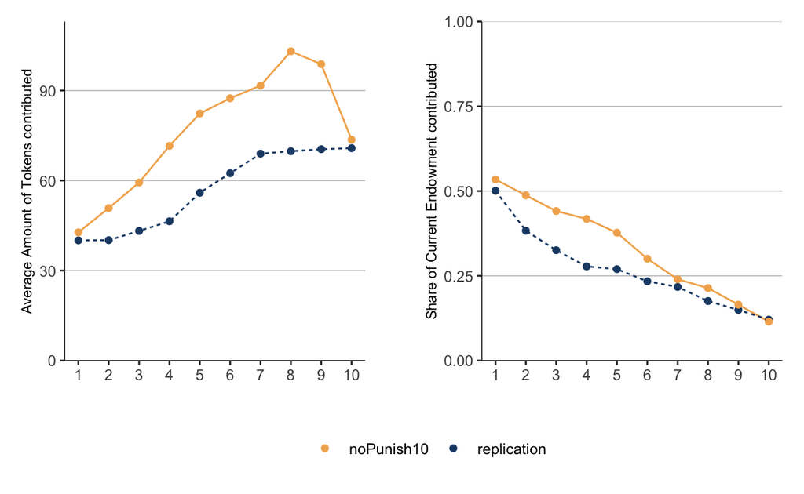

Figure 1: The average amount of tokens contributed over time in treatments.

### Hm..?

The plot above puzzles me a little as the right panel visualizes the mean `share==contribution/endowment` by treatment and round. This yields a different result than the mean of the sum of contributions divided by the sum of endowments per treatment and round as the following table illustrates.

| treatment | round | contribution | endowment | share | sumContBySumEndo |
| --- | --- | --- | --- | --- | --- |
| replication | 10 | 70.7931 | 342.7586 | 0.1208084 | 0.2065392 |
| noPunish10 | 10 | 73.6087 | 439.6957 | 0.1148712 | 0.1674083 |

## Wealth Creation

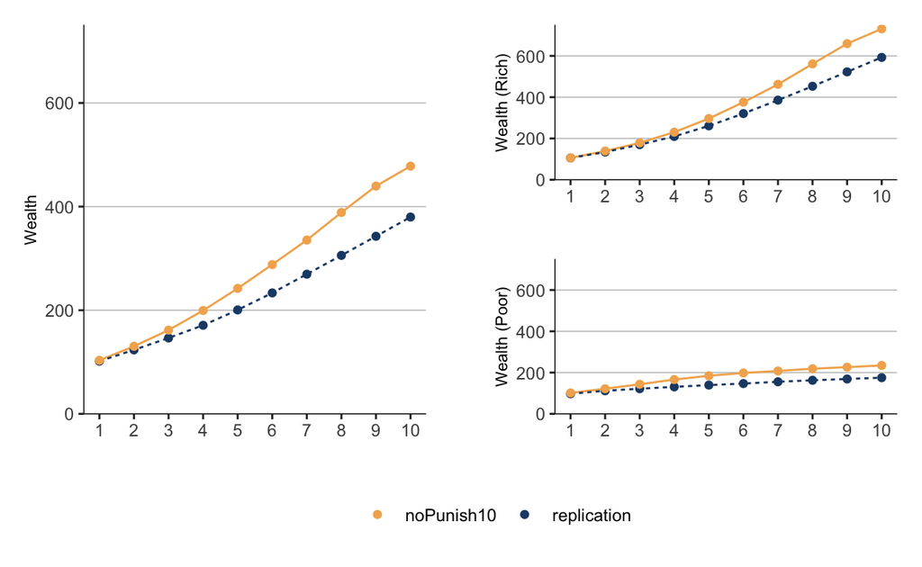

Figure 2: Average wealth over time across treatments.

| Statistic | replication | GMTV |
| --- | --- | --- |
| Mean | 379.828 | 478.087 |
| Median | 262 | 304.000 |
| St. Dev. | 336.059 | 393.575 |
| Max | 1,425 | 1,792.000 |
| Min | 92 | 161.000 |
| N | 29 | 23 |

The two-sided rank sum test (comparing differences between data sources) yields a p-Value of 0.1356 for the mean wealth after the last round of the game.

### Wealth Differences between Data Sources

We next consider whether we were able to replicate GMTV’s results with our data. Absolute contributions tended to be higher in Gächter et al. (2017) but end up at around the same level as in the replication due to a stark decline in contributions on the last round. In terms of shares contributed both data sources exhibit a similar pattern: they decline and do not stabilize. Even though the share of current endowments contributed in the last round is quite similar, the share declined a little faster in our data.

Our groups also tend to be poorer. Median wealth is higher in GMTV. This difference in mean ranks is not significant according to a two-sided ranksum test, however. To assess the statistical significance of differences in means, we run OLS regressions where we regress wealth on a treatment dummy for *Replication* (Table 3). These regressions show that differences in means are only significant for below median groups.

|  | *Dependent variable:* |  |  |
| --- | --- | --- | --- |
|  | Wealth |  |  |
|  | All | Below median | Above median |
| Replication | -98.26 | -59.41*** | -138.21 |
|  | (101.21) | (18.32) | (166.67) |
| Constant | 478.09*** | 234.70*** | 731.00*** |
|  | (75.58) | (13.99) | (124.73) |
| Observations | 52 | 24 | 25 |
| R<sup>2</sup> | 0.02 | 0.32 | 0.03 |
| Residual Std. Error | 362.49 | 44.24 | 413.67 |
| *Note:* | p<0.1; p<0.05; p<0.01 |  |  |

## Inequality

In this subsection, we focus on the amount of inequality created endogenously in our setting. The smallest possible value the Gini coefficient takes is zero (if all four group members own one fourth of the wealth) and the largest possible value it takes is one (if one group member holds the entire wealth). Table 4 shows some summary statistics regarding the Gini coefficient.

The round 10 Gini coefficient ranges between 0.035 and 0.52 in our data with a median of 0.218.

| Statistic | replication | GMTV |
| --- | --- | --- |
| Mean | 0.218 | 0.246 |
| Median | 0.218 | 0.245 |
| St. Dev. | 0.123 | 0.131 |
| Max | 0.520 | 0.479 |
| Min | 0.035 | 0.044 |
| N | 29 | 23 |

The two-sided rank sum test yields a p-Value of 0.4176 for the mean `gini` during the last round of the game.

Figure 3 illustrates the dynamics of the Gini coefficient (at the end of each round) over time and shows that inequality increases slightly.

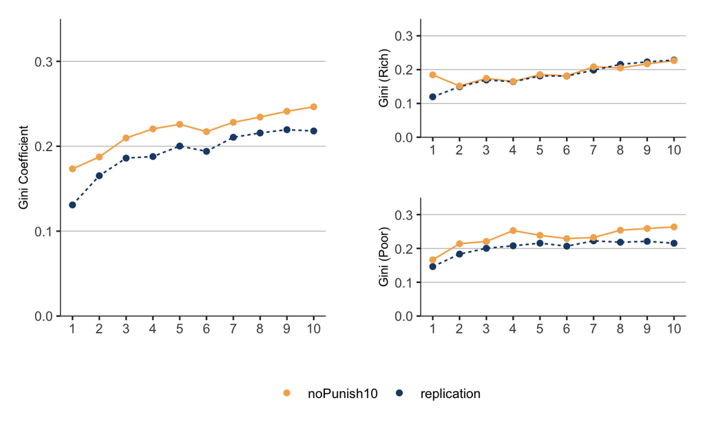

Figure 3: Average Gini coefficient over time across treatments.

### Inequality Differences between Data Sources

Once more, we consider whether we were able to replicate GMTV’s results with our data.

The following table shows a simple OLS regression to illustrate differences in the 10th round’s Gini coefficient between the replication’s data and GMTV’s data. Mean Gini coefficients are similar across data sources and there are no statistically significant differences in mean Gini coefficients.

|  | *Dependent variable:* |  |  |
| --- | --- | --- | --- |
|  | Gini |  |  |
|  | All | Below median | Above median |
| Replication | -0.03 | -0.05 | 0.002 |
|  | (0.04) | (0.06) | (0.05) |
| Constant | 0.25*** | 0.26*** | 0.23*** |
|  | (0.03) | (0.04) | (0.04) |
| Observations | 52 | 24 | 25 |
| R<sup>2</sup> | 0.01 | 0.03 | 0.0001 |
| Residual Std. Error | 0.13 | 0.13 | 0.13 |
| *Note:* | p<0.1; p<0.05; p<0.01 |  |  |

# Time Spent

Participants spent approximately 24 minutes completing the experiment. Reading the instructions and answering the comprehension questions took the most time, that is, 12 minutes. The public goods game required 7 minutes of the participants’ time.

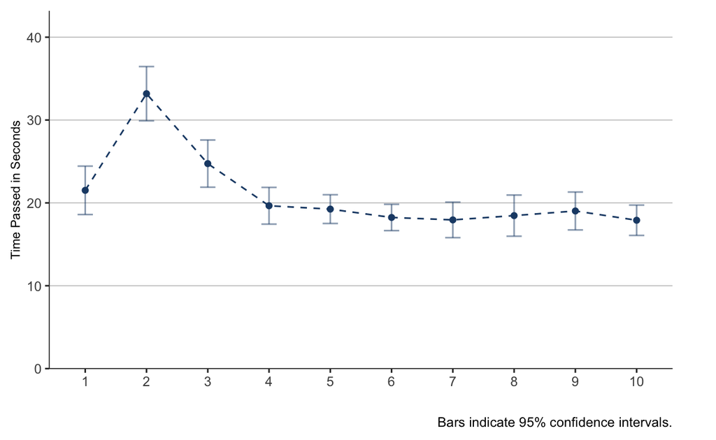

Figure 4: Average Time Spent for each Contribution per Round.

Figure 4 illustrates the time participants needed to make each of their contributions during the replication. One can see that the initial as well as most of the other contributions take about 20 seconds of time. Interestingly, the second contribution takes (on average) about 50% more time than the first one - presumably because this is the first time participants’ learn their respective group members’ actions. The third contribution is a little faster and all subsequent contributions stabilize at 19 seconds.

Given that no participant dropped out after answering the comprehension questions correctly and given that participants need less than 20 seconds to make their contributions, more than 10 rounds are feasible.

# Sample Properties

| Statistic | N | Mean | St. Dev. | Min | Pctl(25) | Pctl(75) | Max |
| --- | --- | --- | --- | --- | --- | --- | --- |
| gender | 116 | 0.526 | 0.501 | 0 | 0 | 1 | 1 |
| age | 116 | 35.767 | 15.663 | 9 | 24 | 49.2 | 73 |
| switching_row | 78 | 6.154 | 2.151 | 1.000 | 6.000 | 7.000 | 12.000 |
| education | 116 | 6.241 | 0.966 | 3 | 6 | 7 | 8 |
| donation | 116 | 0.931 | 1.672 | 0.000 | 0.000 | 1.000 | 11.050 |
| pq01 | 116 | 4.302 | 1.144 | 1 | 3.8 | 5 | 6 |
| pq02 | 116 | 2.681 | 1.702 | 0 | 1 | 4 | 6 |
| pq03 | 116 | 3.759 | 1.184 | 1 | 3 | 5 | 6 |
| pq04 | 116 | 1.853 | 1.551 | 0 | 1 | 2 | 6 |
| pq05 | 116 | 4.284 | 1.207 | 1 | 4 | 5 | 6 |
| pq06 | 116 | 3.672 | 1.525 | 0 | 3 | 5 | 6 |
| pq07 | 116 | 4.879 | 1.463 | 0 | 4 | 6 | 6 |
| pq08 | 116 | 4.647 | 1.385 | 1 | 4 | 6 | 6 |
| pq09 | 116 | 1.560 | 2.006 | 0 | 0 | 3 | 6 |
| pq10 | 116 | 3.009 | 1.639 | 0 | 2 | 4 | 6 |
| pq11 | 116 | 3.586 | 1.358 | 0 | 3 | 5 | 6 |
| pq12 | 116 | 3.914 | 1.564 | 0 | 3 | 5 | 6 |
| pq13 | 116 | 3.836 | 1.480 | 0 | 3 | 5 | 6 |
| pq14 | 116 | 4.241 | 1.618 | 0 | 3 | 6 | 6 |

|  | *Dependent variable:* |  |  |  |
| --- | --- | --- | --- | --- |
|  | female | age | risk | donations |
| Replication | 0.15** | 5.04*** | -0.28 | 0.25 |
|  | (0.07) | (1.65) | (0.27) | (0.23) |
| Constant | 0.38*** | 30.73*** | 6.44*** | 0.68*** |
|  | (0.05) | (1.23) | (0.19) | (0.17) |
| Observations | 208 | 208 | 165 | 208 |
| R<sup>2</sup> | 0.02 | 0.04 | 0.01 | 0.01 |
| Residual Std. Error | 0.50 | 11.83 | 1.76 | 1.66 |
| *Note:* | p<0.1; p<0.05; p<0.01 |  |  |  |

|  | *Dependent variable:* |  |  |  |  |
| --- | --- | --- | --- | --- | --- |
|  | quick thinker | easily offended | very satisfied | very dependent | generally happy |
| Replication | -0.77*** | -1.03*** | -1.23*** | -0.94*** | -1.36*** |
|  | (0.17) | (0.23) | (0.17) | (0.20) | (0.16) |
| Constant | 5.08*** | 3.71*** | 4.99*** | 2.79*** | 5.64*** |
|  | (0.13) | (0.17) | (0.13) | (0.15) | (0.12) |
| Observations | 208 | 208 | 208 | 208 | 208 |
| R<sup>2</sup> | 0.09 | 0.09 | 0.21 | 0.09 | 0.26 |
| Residual Std. Error | 1.20 | 1.66 | 1.21 | 1.46 | 1.15 |
| *Note:* | p<0.1; p<0.05; p<0.01 |  |  |  |  |

|  | *Dependent variable:* |  |  |  |  |
| --- | --- | --- | --- | --- | --- |
|  | work important | family important | friends important | religion important | politics important |
| Replication | -1.04*** | -0.61*** | -1.30*** | -0.87*** | -0.69*** |
|  | (0.20) | (0.21) | (0.18) | (0.26) | (0.22) |
| Constant | 4.72*** | 5.49*** | 5.95*** | 2.43*** | 3.70*** |
|  | (0.15) | (0.16) | (0.13) | (0.20) | (0.16) |
| Observations | 208 | 208 | 208 | 208 | 208 |
| R<sup>2</sup> | 0.11 | 0.04 | 0.20 | 0.05 | 0.05 |
| Residual Std. Error | 1.46 | 1.51 | 1.28 | 1.88 | 1.58 |
| *Note:* | p<0.1; p<0.05; p<0.01 |  |  |  |  |

|  | *Dependent variable:* |  |  |  |
| --- | --- | --- | --- | --- |
|  | most people trusted | hard work better | government responsible | incomes equal |
| Replication | -0.28 | -1.52*** | -0.48** | 0.42* |
|  | (0.19) | (0.21) | (0.20) | (0.23) |
| Constant | 3.87*** | 5.43*** | 4.32*** | 3.83*** |
|  | (0.14) | (0.16) | (0.15) | (0.17) |
| Observations | 208 | 208 | 208 | 208 |
| R<sup>2</sup> | 0.01 | 0.20 | 0.03 | 0.02 |
| Residual Std. Error | 1.36 | 1.52 | 1.42 | 1.63 |
| *Note:* | p<0.1; p<0.05; p<0.01 |  |  |  |

|  | *Dependent variable:* |  |  |  |
| --- | --- | --- | --- | --- |
|  | Wealth |  | Gini |  |
| female | -30.63 | -65.02 | 0.02 | 0.02 |
|  | (88.07) | (83.80) | (0.03) | (0.03) |
| age | 7.05* | 9.00** | -0.001 | -0.001 |
|  | (3.82) | (3.60) | (0.001) | (0.001) |
| risk | 27.21 | 10.98 | -0.01 | -0.01 |
|  | (22.65) | (19.45) | (0.01) | (0.01) |
| quick thinker | -55.19 |  | 0.02 |  |
|  | (45.52) |  | (0.02) |  |
| easily offended | -26.52 |  | 0.01 |  |
|  | (31.48) |  | (0.01) |  |
| very satisfied | -2.62 |  | 0.001 |  |
|  | (42.60) |  | (0.02) |  |
| very dependent | -22.41 |  | 0.0003 |  |
|  | (30.47) |  | (0.01) |  |
| generally happy | 70.06 |  | 0.004 |  |
|  | (42.99) |  | (0.02) |  |
| work important | -64.01 |  | -0.01 |  |
|  | (39.13) |  | (0.02) |  |
| family important | 11.99 |  | -0.01 |  |
|  | (38.05) |  | (0.01) |  |
| friends important | -24.05 |  | -0.004 |  |
|  | (37.94) |  | (0.01) |  |
| religion important | -20.48 |  | 0.02* |  |
|  | (26.15) |  | (0.01) |  |
| politics important | 86.94*** |  | -0.01 |  |
|  | (30.79) |  | (0.01) |  |
| most people trusted | -0.49 |  | -0.001 |  |
|  | (31.94) |  | (0.01) |  |
| hard work better | 35.38 |  | -0.03* |  |
|  | (34.46) |  | (0.01) |  |
| government responsible | -47.38 |  | -0.03* |  |
|  | (39.54) |  | (0.02) |  |
| incomes equal | -9.13 |  | 0.01 |  |
|  | (33.79) |  | (0.01) |  |
| Constant | 278.16 | 100.12 | 0.39*** | 0.28*** |
|  | (377.35) | (180.67) | (0.14) | (0.07) |
| Observations | 78 | 78 | 78 | 78 |
| R<sup>2</sup> | 0.28 | 0.10 | 0.21 | 0.02 |
| Residual Std. Error | 357.69 | 360.58 | 0.14 | 0.14 |
| *Note:* | p<0.1; p<0.05; p<0.01 |  |  |  |
|  | Robust standard errors in parentheses, clustered by group ID. |  |  |  |

# Hamburg: How do Students compare to non-Students?

This section considers the replication data only. Doing so, we’ll exploit the circumstance that we recruited from both the convenience or “student” sample as well as the non-convenience sample *(Hamburg Panel)* and analyze the differences between the two.

| Statistic | Students | HH.panel |
| --- | --- | --- |
| Mean | 10.172 | 9.827 |
| Median | 10 | 10.000 |
| St. Dev. | 6.470 | 6.233 |
| Max | 20 | 20.000 |
| Min | 0 | 0.000 |
| N | 64 | 52 |

We start by looking at the initial contributions. As Table 5 illustrates, there is no difference in averages, standard deviation or the range. The two-sided rank sum test (comparing differences between data sources) yields a p-Value of 0.8902 for the mean contribution in first round of the game.

While the initial contributions are on average quite similar between the two sample, the subsequent contributions differ. In both absolute and relative terms, the Hamburg-Panel tends to contribute more than the student sample as the following Figure shows.

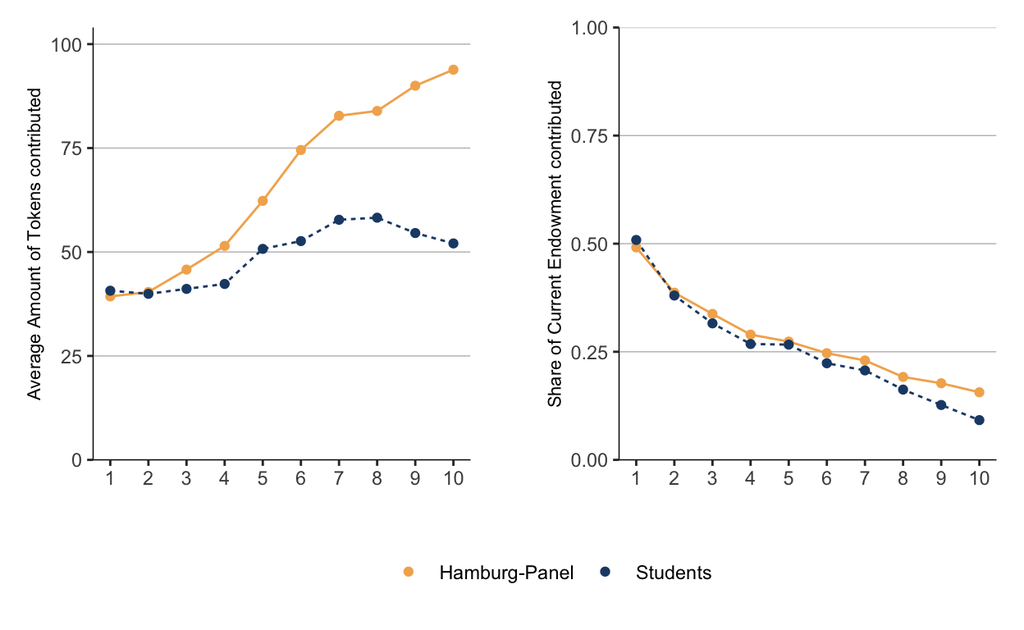

Differences in contributions lead to differences in wealth. The Hamburg-Panel therefore earned more during the public goods game than the student sample. This can be seen in the following figure as well as in the subsequent table:

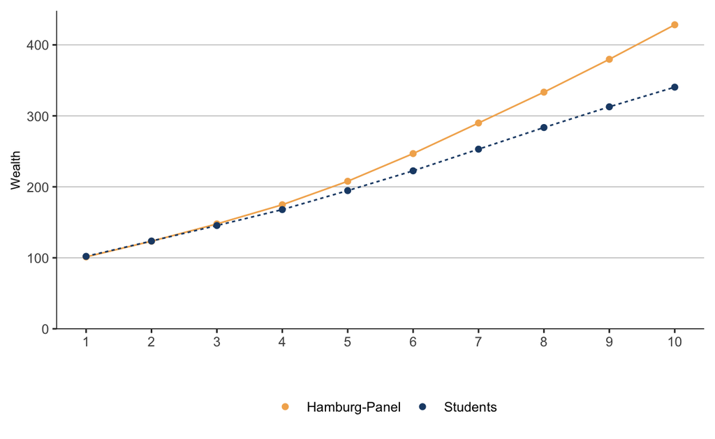

Figure 5: Average wealth over time across samples.

| round | student | contribution | share | stock |
| --- | --- | --- | --- | --- |
| 10 | FALSE | 93.84615 | 0.1563321 | 428.3077 |
| 10 | TRUE | 52.06250 | 0.0919455 | 340.4375 |

Berlemann, Michael, Hauke Roggenkamp, and Stefan Traub. 2021. “Replication: Growth and Inequality in Public Good Provision (No-Punish-10) by gächter Et Al. (2017).” *AEA RCT Registry*. https://doi.org/https://doi.org/10.1257/rct.7902-2.0.

Bock, Olaf, Ingmar Baetge, and Andreas Nicklisch. 2014. “Hroot: Hamburg Registration and Organization Online Tool.” *European Economic Review* 71: 117–20. https://doi.org/https://doi.org/10.1016/j.euroecorev.2014.07.003.

Chen, Daniel L., Martin Schonger, and Chris Wickens. 2016. “oTree-an Open-Source Platform for Laboratory, Online, and Field Experiments.” *Journal of Behavioral and Experimental Finance* 9: 88–97. https://doi.org/10.1016/j.jbef.2015.12.001.

Fehr, Ernst, and Simon Gächter. 2000. “Cooperation and Punishment in Public Goods Experiments.” *American Economic Review* 90 (4): 980–94. https://doi.org/10.1257/aer.90.4.980.

Gächter, Simon, Friederike Mengel, Elias Tsakas, and Alexander Vostroknutov. 2017. “Growth and Inequality in Public Good Provision.” *Journal of Public Economics* 150: 1–13. https://doi.org/10.1016/j.jpubeco.2017.03.002.

[^1]: Taken together with inefficient growth and the lack of dropouts, additional rounds are fairly cheap.
[^2]: See Figure 3B in Fehr and Gächter (2000), for instance.
[^3]: Participants contribute about 10 tokens in the first round